# GGPlot Exercises

Xuhao Dong

## Introduction

This document takes us through some common charting challenges with `ggplot`. Much of this code is reinforced or introduced in the “Data Visualization” chapter of *Algorithms for Data Science*.

When you submit your work, please submit both your RMD file and the knitted HTML file. Save the data for this assignment in the same folder as the RMD and the reads should work.

```r
gd <- read_tsv("grocery_data.txt")
month.summary <- read_tsv("month_summary.txt")
dept.summary <- read_tsv("dept_summary.txt")
```

```r
mosaic.data <- read_tsv("counts_for_mosaic.txt")
```

## Problem 1 - Sales by month by department

Things to add to this chart:

- Divide sales by 1000
- Add some transparency to the points with `alpha`
- Add axis labels using `labs`
- Center the title, rather than it being left-aligned

```r
gd <- gd %>%
    mutate(month = as.factor(month),
           departmentName = reorder(departmentName,ownerSales,mean))
head(gd,10)
```

```
## # A tibble: 10 x 9
##     year month dept_no departmentName numOwners ownerSales totalQty transactions
##    <dbl> <fct>   <dbl> <fct>              <dbl>      <dbl>    <dbl>        <dbl>
##  1  2013 06          1 PACKAGED GROC…      2096     91234.   30132          6783
##  2  2013 06          2 PRODUCE             2019    105706.  201990.         6565
##  3  2013 06          3 BULK                1497     37440.   13515.         3367
##  4  2013 06          4 REF GROCERY         1863     46426.   15792          5232
##  5  2013 06          5 CHEESE              1074     13326     1720.         2261
##  6  2013 06          6 FROZEN              1137     19144.    4822.         2224
##  7  2013 06          7 BREAD                632      4829.    1633          1074
##  8  2013 06          8 DELI                1361     30804.   81013.         3691
##  9  2013 06          9 GEN MERCH            586      5819.   84073.          811
## 10  2013 06         10 SUPPLEMENTS          633     23382.    5645           930
## # … with 1 more variable: Items <dbl>
```

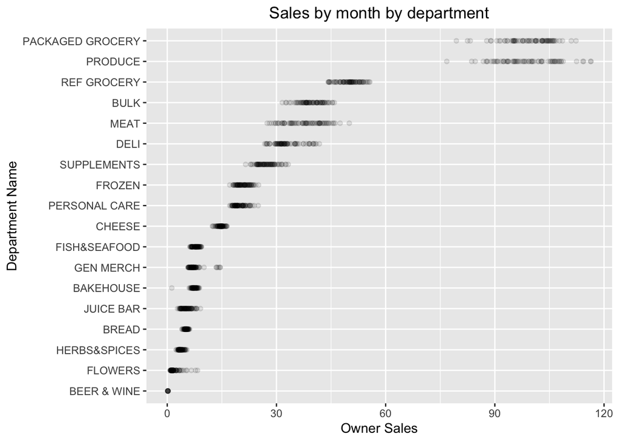

```r
# Here's a basic one:
plot <- ggplot(gd, aes(x=(sales = ownerSales / 1000),y=departmentName)) +
  geom_point(alpha = 1/10)

plot <- plot + labs(x = "Owner Sales", y = "Department Name")

plot <- plot +
  ggtitle("Sales by month by department") +
  theme(plot.title = element_text(hjust = 0.5))

print(plot)
```

## Problem 2 - add median lines

Add these lines to the plot using geom_segment.

- That function/layer takes four values
- x, xend, y, and y.end. You can get y.values with
- something like `as.numeric(departmentName)-0.5` (or plus)
- The x’s should be the median values

```r
medians <- gd %>%
  group_by(departmentName) %>%
  summarise(med.val = median(ownerSales/1000))

medians
```

```
## # A tibble: 18 x 2
##    departmentName   med.val
##    <fct>              <dbl>
##  1 BEER & WINE        0.172
##  2 FLOWERS            1.57
##  3 HERBS&SPICES       3.62
##  4 BREAD              5.14
##  5 JUICE BAR          5.13
##  6 BAKEHOUSE          7.36
##  7 GEN MERCH          7.10
##  8 FISH&SEAFOOD       7.88
##  9 CHEESE            14.8
## 10 PERSONAL CARE     19.4
## 11 FROZEN            20.7
## 12 SUPPLEMENTS       27.0
## 13 DELI              32.1
## 14 MEAT              38.1
## 15 BULK              39.2
## 16 REF GROCERY       50.2
## 17 PRODUCE           98.1
## 18 PACKAGED GROCERY 101.
```

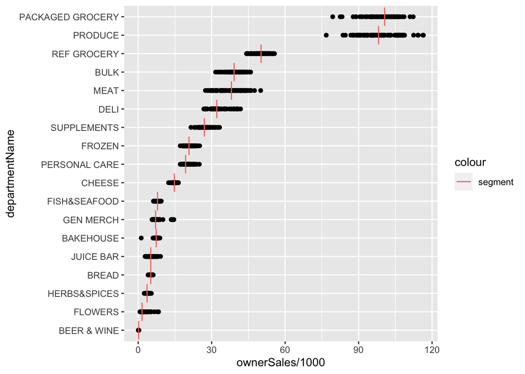

```r
ggplot(gd, aes(x=ownerSales/1000,y=departmentName)) +
  geom_point() +
  geom_segment(aes(x = med.val, y = as.numeric(departmentName)-0.5, xend = med.val, yend = as.numeric(departmentName)+0.5, colour = "segment"), data = medians)
```

## Problem 3 - line chart plotting the density

Things to add:

- a theme (could use `theme_minimal`)
- label each line using `geom_text`
- Each label should read “Bandwidth = x”
- Make sure labels don’t overlap the line (use `check_overlap=T` within `geom_text` to accomplish this)
- Each label should match the color of the line its labeling

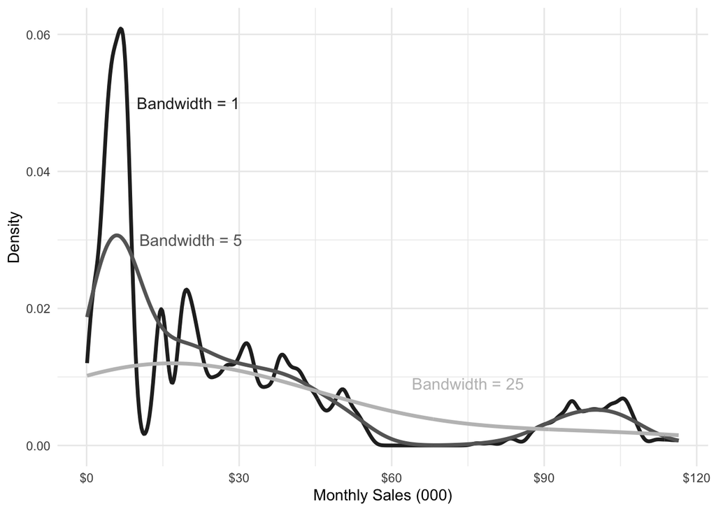

```r
p3.size <- 4
p3.cols <- c("gray15","gray40","gray75")
p <- ggplot(gd,
            aes(x=ownerSales/1000)) +
  ylab("Density") +
  geom_line(stat="density",col=p3.cols[1],size=1.25,bw=1) +
  geom_line(stat="density",col=p3.cols[2],size=1.25,bw=5) +
  geom_line(stat="density",col=p3.cols[3],size=1.25,bw=25) +
  scale_x_continuous(label=dollar) +
  xlab("Monthly Sales (000)") +
  geom_text(aes(x=20,y=0.05),
            label= 'Bandwidth = 1',
            size=p3.size, check_overlap = T, col=p3.cols[1]) +
  geom_text(aes(x=20.5,y=0.03),
            label= 'Bandwidth = 5',
            size=p3.size, check_overlap = T, col=p3.cols[2]) +
  geom_text(aes(x=75,y=0.009),
            label='Bandwidth = 25',
            size=p3.size, check_overlap = T, col=p3.cols[3]) +
  theme_minimal()

print(p)
```

## Problem 4 - use `gd` to create a density plot of sales by department.

Things to add:

- First, make a density plot of sales (using `geom_density`).
- Then facet that plot by department using `facet_wrap`
- Change the x axis tick marks so they are easily readable

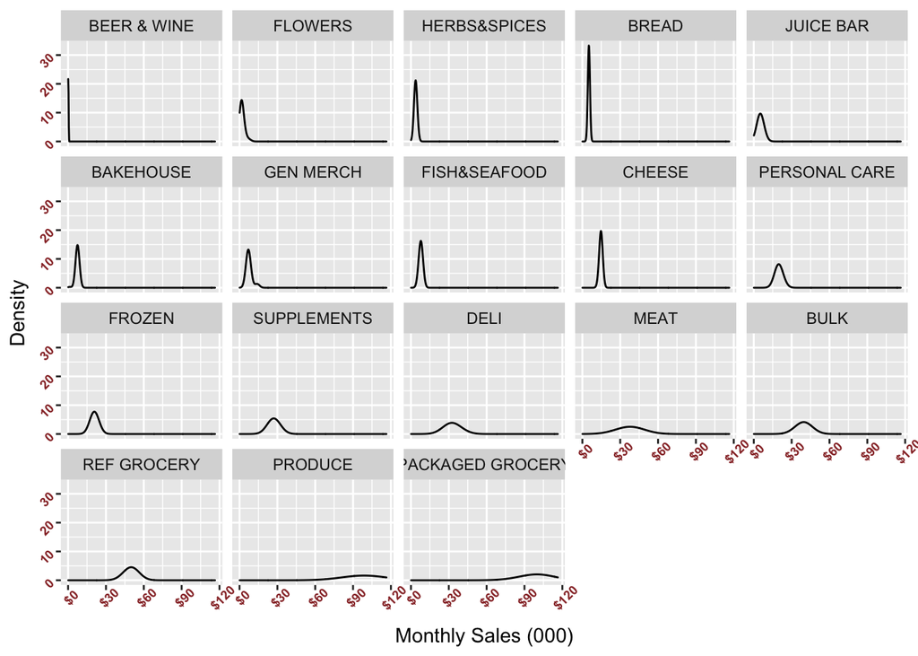

```r
den <- ggplot(gd, aes(ownerSales/1000, ..count..)) +
  geom_density(adjust = 5) +
  ylab("Density") +
  scale_x_continuous(label=dollar) +
  xlab("Monthly Sales (000)")

den2 <- den + facet_wrap(vars(departmentName))

den3 <- den2 + theme(axis.text.x = element_text(face="bold", color="#993333",
                           size=7, angle=45),
          axis.text.y = element_text(face="bold", color="#993333",
                           size=7, angle=45))
den3
```

## Problem 5 - violin plots! Use gd, build violin plots of ownerSales by department.

Things to add:

- add quantile lines, use nice labels,
- re-orient chart with departments on the y-axis
- add a vertical line for the overall mean and change its color
- add an annotation to the mean line with the mean sales

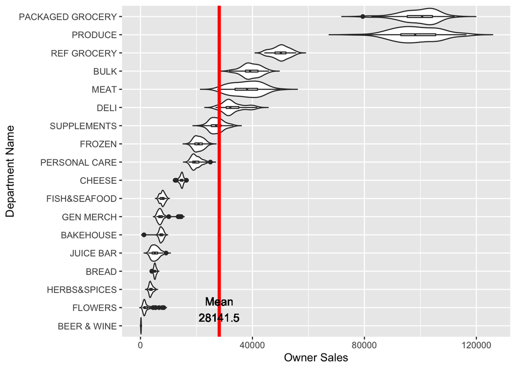

```r
mean <- gd %>%
  pull(ownerSales) %>%
  mean() %>%
  signif(6)

v <- ggplot(gd, aes(ownerSales,departmentName)) +
  xlab("Owner Sales")+
  ylab("Department Name")+
  geom_violin(scale='width',trim=FALSE) +
  geom_boxplot(width=0.1) +
  geom_vline(xintercept=mean,size=1.5, color="red")+
  geom_text(aes(x=mean, label=paste0("Mean\n",mean), y=1.9))

v
```

## Problem 6 - Mosaic charts

Things to add:

- Using mosaic.table, create a mosaic plot
- Color the mosaicplot using the default gray pallette.

```r
mosaic.table <- mosaic.data %>%
  spread(Segment,count) %>%
  rename(Dept=DepartmentName) %>%
  arrange(Primary) %>%
  as.data.frame

head(mosaic.table,10)
```

```
##               Dept Light Primary Secondary
## 1      SUPPLEMENTS   439   90017     55657
## 2           CHEESE   859  147679     96987
## 3             MEAT   653  149251    107350
## 4           FROZEN   647  152940     97808
## 5             DELI  5830  155086    138722
## 6             BULK  2713  178520    144862
## 7      REF GROCERY  3491  197463    194758
## 8          PRODUCE  3971  199978    211226
## 9 PACKAGED GROCERY  6980  200737    223815
```

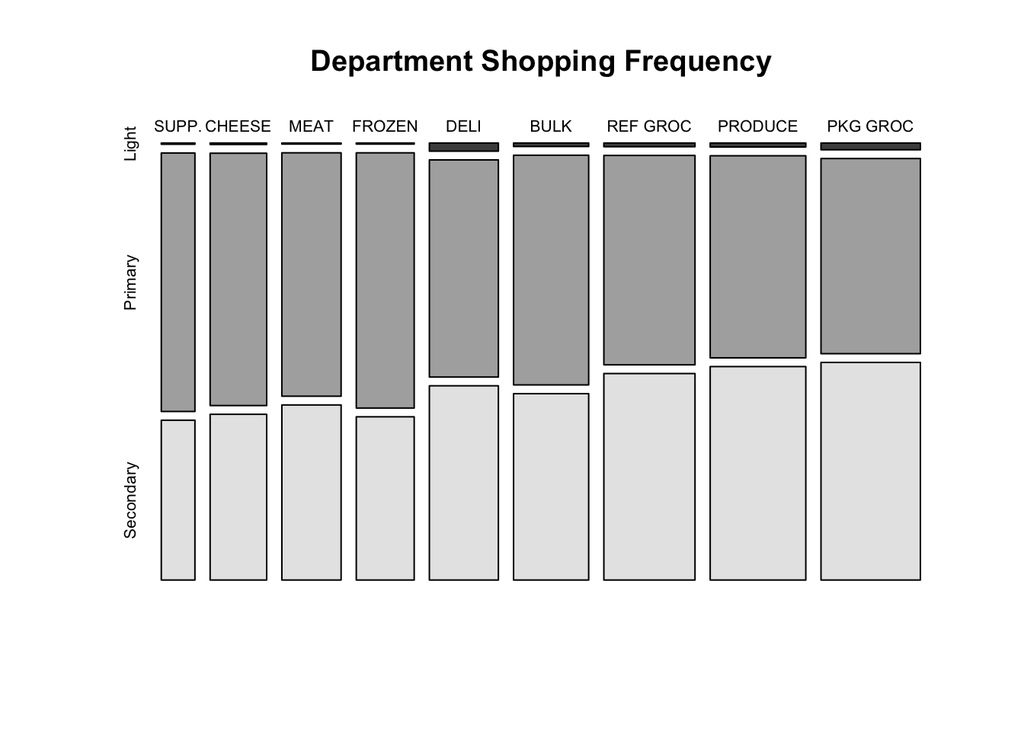

```r
# Let's do some renaming
row.names(mosaic.table) <- mosaic.table$Dept
mosaic.table$Dept <- NULL

rownames(mosaic.table)[rownames(mosaic.table)=="SUPPLEMENTS"] <- "SUPP."
rownames(mosaic.table)[rownames(mosaic.table)=="REF GROCERY"] <- "REF GROC"
rownames(mosaic.table)[rownames(mosaic.table)=="PACKAGED GROCERY"] <- "PKG GROC"

mosaicplot(mosaic.table, color = TRUE, main = "Department Shopping Frequency")
```